# Project 1: Wrangling, Exploration, Visualization

SDS322E

## Data Wrangling, Exploration, Visualization

### Tran Nguyen, tnn649

#### Introduction

```r
library(tidyverse)
library(kableExtra)
guns <- read_csv("Guns.csv")
schoolspend <- read_csv("Guber99.csv")
```

*I have one dataset that is about school expenditure and test scores by state and another that is about guns and crime data by state including D.C. The ‘schoolspend’ dataset has 50 observations and 9 variables and the ‘guns’ dataset consists of 1173 observations and 14 variables.*

*I am interested in these two data sets because I wanted to see the trend between school expenditure crime by state. To be completely honest, I am not sure what to expect but I thought it would be an interesting pair to take a look at. If I were to predict anything, I would think that there would be an inverse relationship between school spending and crime because I expect schools in states that are spending less will also show a trend in gun violence.*

#### Tidying: Reshaping

```r
messy <- guns %>% pivot_wider(names_from = "state", values_from = "population")

retidied <- messy %>% pivot_longer(c("Alabama":"Wyoming"), names_to = "state",
    values_to = "population", values_drop_na = T)
```

#### Joining/Merging

```r
glimpse(guns)
```

```
## Rows: 1,173
## Columns: 14
## $ X1         <dbl> 1, 2, 3, 4, 5, 6, 7, 8, 9, 10, 11, 12, 13, 14, 15, 16, 17,…
## $ year       <dbl> 1977, 1978, 1979, 1980, 1981, 1982, 1983, 1984, 1985, 1986…
## $ violent    <dbl> 414.4, 419.1, 413.3, 448.5, 470.5, 447.7, 416.0, 431.2, 45…
## $ murder     <dbl> 14.2, 13.3, 13.2, 13.2, 11.9, 10.6, 9.2, 9.4, 9.8, 10.1, 9…
## $ robbery    <dbl> 96.8, 99.1, 109.5, 132.1, 126.5, 112.0, 98.4, 96.1, 105.4,…
## $ prisoners  <dbl> 83, 94, 144, 141, 149, 183, 215, 243, 256, 267, 283, 307, …
## $ afam       <dbl> 8.384873, 8.352101, 8.329575, 8.408386, 8.483435, 8.514000…
## $ cauc       <dbl> 55.12291, 55.14367, 55.13586, 54.91259, 54.92513, 54.89621…
## $ male       <dbl> 18.17441, 17.99408, 17.83934, 17.73420, 17.67372, 17.51052…
## $ population <dbl> 3.780403, 3.831838, 3.866248, 3.900368, 3.918531, 3.925229…
## $ income     <dbl> 9563.148, 9932.000, 9877.028, 9541.428, 9548.351, 9478.919…
## $ density    <dbl> 0.0745524, 0.0755667, 0.0762453, 0.0768288, 0.0771866, 0.0…
## $ state      <chr> "Alabama", "Alabama", "Alabama", "Alabama", "Alabama", "Al…
## $ law        <chr> "no", "no", "no", "no", "no", "no", "no", "no", "no", "no"…
```

```r
glimpse(schoolspend)
```

```
## Rows: 50
## Columns: 9
## $ X1         <dbl> 1, 2, 3, 4, 5, 6, 7, 8, 9, 10, 11, 12, 13, 14, 15, 16, 17,…
## $ state      <chr> "Alabama", "Alaska", "Arizona", "Arkansas", "California", …
## $ expendpp   <dbl> 4.405, 8.963, 4.778, 4.459, 4.992, 5.443, 8.817, 7.030, 5.…
## $ ptratio    <dbl> 17.2, 17.6, 19.3, 17.1, 24.0, 18.4, 14.4, 16.6, 19.1, 16.3…
## $ tsalary    <dbl> 31.144, 47.951, 32.175, 28.934, 41.078, 34.571, 50.045, 39…
## $ perctakers <dbl> 8, 47, 27, 6, 45, 29, 81, 68, 48, 65, 57, 15, 13, 58, 5, 9…
## $ verbal     <dbl> 491, 445, 448, 482, 417, 462, 431, 429, 420, 406, 407, 468…
## $ math       <dbl> 538, 489, 496, 523, 485, 518, 477, 468, 469, 448, 482, 511…
## $ total      <dbl> 1029, 934, 944, 1005, 902, 980, 908, 897, 889, 854, 889, 9…
```

```r
joined_guns_spend <- inner_join(guns, schoolspend, by = "state")
```

*Here, I inner joined my datasets by state. The ‘schoolspend’ dataset originally had 50 observations and the ‘guns’ dataset had 1173. With an inner join, the observations were 1150 because the ‘guns’ dataset included observations from Washington D.C. which is not included in the ‘schoolspend’ dataframe. From the ‘guns’ set, 23 District of Columbia rows were dropped and each unique ID represented the data for a state for that year. For the schoolspend dataset, each unique ID represents the information for a single state. I chose to do an inner join because there are columns in both datasets that I am interested in looking at. I wanted to retain the ‘expendpp’ from the ‘schoolspend’ dataframe and ‘violent’ from the ‘guns’ dataframe. Since the inner_join() function retains all the original columns and just drops the observations that don’t match, I felt it would be a good fit for my purposes.*

#### Wrangling

```r
# Converting 'expendpp' into normal dollars
joined_guns_spend
```

```
## # A tibble: 1,150 x 22
##     X1.x  year violent murder robbery prisoners  afam  cauc  male population
##    <dbl> <dbl>   <dbl>  <dbl>   <dbl>     <dbl> <dbl> <dbl> <dbl>      <dbl>
##  1     1  1977    414.   14.2    96.8        83  8.38  55.1  18.2       3.78
##  2     2  1978    419.   13.3    99.1        94  8.35  55.1  18.0       3.83
##  3     3  1979    413.   13.2   110.        144  8.33  55.1  17.8       3.87
##  4     4  1980    448.   13.2   132.        141  8.41  54.9  17.7       3.90
##  5     5  1981    470.   11.9   126.        149  8.48  54.9  17.7       3.92
##  6     6  1982    448.   10.6   112         183  8.51  54.9  17.5       3.93
##  7     7  1983    416     9.2    98.4       215  8.55  54.8  17.4       3.93
##  8     8  1984    431.    9.4    96.1       243  8.56  54.8  17.1       3.95
##  9     9  1985    458.    9.8   105.        256  8.56  54.7  16.9       3.97
## 10    10  1986    558    10.1   112.        267  8.57  54.5  16.6       3.99
## # … with 1,140 more rows, and 12 more variables: income <dbl>, density <dbl>,
## #   state <chr>, law <chr>, X1.y <dbl>, expendpp <dbl>, ptratio <dbl>,
## #   tsalary <dbl>, perctakers <dbl>, verbal <dbl>, math <dbl>, total <dbl>
```

```r
year94_set <- joined_guns_spend %>% select(2:6, 10:11, 13:14,
    16:19, 22) %>% filter(year == "1994") %>% group_by(state) %>%
    mutate(expendpp = expendpp * 1000) %>% mutate(state = str_replace(state,
    " ", "_"))
# replacing spaces with _ because I don't like spaces in my
# data
```

*Here, I replaced the spaces between states whose names are made up of two words just to keep everything consistent and straightforward. I converted the ‘expendpp’ into dollars because it is easier for me to conceptualize it that way and it also lets me compare it to other columns without having to mess with the inconsistent units and measurements. I’ve also decided to take a subset of the fullset because not all the years line up in both datasets so I chose a year that had overlap and I only selected the columns which I would be doing anything with. Additionally, I am more interested in seeing the differences between states rather than across time for the sake of consistency.*

```r
# How far teacher salary per state is from mean per capital
# income per state
year94_set <- year94_set %>% mutate(tsalary = tsalary * 1000)
year94_set <- year94_set %>% group_by(state) %>% mutate(tsalarydist = abs(income -
    tsalary))
year94_set %>% group_by(state) %>% arrange(-tsalarydist)
```

```
## # A tibble: 50 x 15
## # Groups:   state [50]
##     year violent murder robbery prisoners population income state law   expendpp
##    <dbl>   <dbl>  <dbl>   <dbl>     <dbl>      <dbl>  <dbl> <chr> <chr>    <dbl>
##  1  1994    766.    6.3   146.        446      0.601 16970. Alas… no        8963
##  2  1994    966.   11.1   477.        354     18.2   17713. New_… no        9623
##  3  1994    456.    6.6   188.        320      3.27  20518. Conn… no        8817
##  4  1994    427.    5.9   187.        216     12.0   15365. Penn… yes       7109
##  5  1994    614.    5     288         301      7.92  18739. New_… no        9774
##  6  1994    766.    9.8   229.        414      9.58  15363. Mich… no        6994
##  7  1994    376.    4.1    87.3       172      0.993 15296. Rhod… no        7469
##  8  1994   1013    11.8   357.        368     31.3   15774. Cali… no        4992
##  9  1994    521.    4.9   138.        166      3.09  14395. Oreg… yes       6436
## 10  1994    270.    4.5   113.        166      5.10  14582. Wisc… no        6930
## # … with 40 more rows, and 5 more variables: ptratio <dbl>, tsalary <dbl>,
## #   perctakers <dbl>, total <dbl>, tsalarydist <dbl>
```

*In this chunk, I calculated the distance between teacher salary per state and each state’s per capita income. I started by converting the salaries into dollars so it’s consistent with the measure for income. It was interested to see there were a lot of east coast states that had large income disparity between the per capita income and teacher salary income and the states with generally lower per capita averages had the least pay disparity.*

```r
# summary stats based on whether the state have a carry law
# in effect (violence)
year94_set %>% group_by(law) %>% summarize(mean(violent))
```

```
## # A tibble: 2 x 2
##   law   `mean(violent)`
##   <chr>           <dbl>
## 1 no               628.
## 2 yes              406.
```

```r
year94_set %>% group_by(law) %>% summarize(sd(violent))
```

```
## # A tibble: 2 x 2
##   law   `sd(violent)`
##   <chr>         <dbl>
## 1 no             238.
## 2 yes            306.
```

```r
year94_set %>% group_by(law) %>% summarize(median(violent))
```

```
## # A tibble: 2 x 2
##   law   `median(violent)`
##   <chr>             <dbl>
## 1 no                 652.
## 2 yes                304.
```

```r
year94_set %>% group_by(law) %>% summarize(min(violent))
```

```
## # A tibble: 2 x 2
##   law   `min(violent)`
##   <chr>          <dbl>
## 1 no             262.
## 2 yes             81.8
```

```r
year94_set %>% group_by(law) %>% summarize(max(violent))
```

```
## # A tibble: 2 x 2
##   law   `max(violent)`
##   <chr>          <dbl>
## 1 no             1030.
## 2 yes            1147.
```

```r
# summary stats based on whether the state have a carry law
# in effect (murder)
year94_set %>% group_by(law) %>% summarize(mean(murder))
```

```
## # A tibble: 2 x 2
##   law   `mean(murder)`
##   <chr>          <dbl>
## 1 no              7.71
## 2 yes             5.82
```

```r
year94_set %>% group_by(law) %>% summarize(sd(murder))
```

```
## # A tibble: 2 x 2
##   law   `sd(murder)`
##   <chr>        <dbl>
## 1 no            3.30
## 2 yes           5.25
```

```r
year94_set %>% group_by(law) %>% summarize(median(murder))
```

```
## # A tibble: 2 x 2
##   law   `median(murder)`
##   <chr>            <dbl>
## 1 no                 6.9
## 2 yes                4.9
```

```r
year94_set %>% group_by(law) %>% summarize(min(murder))
```

```
## # A tibble: 2 x 2
##   law   `min(murder)`
##   <chr>         <dbl>
## 1 no              1.7
## 2 yes             0.2
```

```r
year94_set %>% group_by(law) %>% summarize(max(murder))
```

```
## # A tibble: 2 x 2
##   law   `max(murder)`
##   <chr>         <dbl>
## 1 no             12
## 2 yes            19.8
```

```r
# summary stats based on whether the state have a carry law
# in effect (robbery)
year94_set %>% group_by(law) %>% summarize(mean(robbery))
```

```
## # A tibble: 2 x 2
##   law   `mean(robbery)`
##   <chr>           <dbl>
## 1 no               184.
## 2 yes              107.
```

```r
year94_set %>% group_by(law) %>% summarize(sd(robbery))
```

```
## # A tibble: 2 x 2
##   law   `sd(robbery)`
##   <chr>         <dbl>
## 1 no            106.
## 2 yes            99.7
```

```r
year94_set %>% group_by(law) %>% summarize(median(robbery))
```

```
## # A tibble: 2 x 2
##   law   `median(robbery)`
##   <chr>             <dbl>
## 1 no                162
## 2 yes                63.6
```

```r
year94_set %>% group_by(law) %>% summarize(min(robbery))
```

```
## # A tibble: 2 x 2
##   law   `min(robbery)`
##   <chr>          <dbl>
## 1 no              16.6
## 2 yes             11.1
```

```r
year94_set %>% group_by(law) %>% summarize(max(robbery))
```

```
## # A tibble: 2 x 2
##   law   `max(robbery)`
##   <chr>          <dbl>
## 1 no              477.
## 2 yes             329.
```

*In each of these, I calculated the basic descriptives for violence, robbery, and murder based on whether a state had a carrying law in place in 1994. For violence, it seemed that there was a higher average in states that did not have a carrying law than states that do. Murders seem to have a higher average in states that don’t have a carrying law versus states that do. This also seems to be the case for robberies as well. It seems that generally speaking, based on these crimes, the rate of them tend to be higher in states that did not have a carrying law.*

```r
# Portion of prisoners to population per state
year94_set <- year94_set %>% mutate(populationBig = population *
    1e+06)
year94_set %>% group_by(state) %>% summarise(prisonerRatio = prisoners/populationBig)
```

```
## # A tibble: 50 x 2
##    state       prisonerRatio
##    <chr>               <dbl>
##  1 Alabama         0.000102
##  2 Alaska          0.000743
##  3 Arizona         0.000104
##  4 Arkansas        0.000133
##  5 California      0.0000118
##  6 Colorado        0.0000717
##  7 Connecticut     0.0000979
##  8 Delaware        0.000556
##  9 Florida         0.0000275
## 10 Georgia         0.0000549
## # … with 40 more rows
```

*Here, I looked at the proportion of prisoners per state to the population size. I see this often as a statistic so I thought it might be helpful to compute. I was able to do this by converting the population in millions to the true size so that the comparing units are equivalent.*

```r
# summary stats based on whether the state have a carry law
# in effect (school spending)
year94_set %>% group_by(law) %>% summarize(max(expendpp))
```

```
## # A tibble: 2 x 2
##   law   `max(expendpp)`
##   <chr>           <dbl>
## 1 no               9774
## 2 yes              7109
```

```r
# summary stats based on whether the state have a carry law
# in effect (SAT scores)
year94_set %>% group_by(law) %>% summarize(mean(total))
```

```
## # A tibble: 2 x 2
##   law   `mean(total)`
##   <chr>         <dbl>
## 1 no             968.
## 2 yes            962.
```

```r
year94_set %>% group_by(law) %>% summarize(sd(total))
```

```
## # A tibble: 2 x 2
##   law   `sd(total)`
##   <chr>       <dbl>
## 1 no           74.3
## 2 yes          78.0
```

```r
year94_set %>% group_by(law) %>% summarize(median(total))
```

```
## # A tibble: 2 x 2
##   law   `median(total)`
##   <chr>           <dbl>
## 1 no                975
## 2 yes               937
```

```r
year94_set %>% group_by(law) %>% summarize(min(total))
```

```
## # A tibble: 2 x 2
##   law   `min(total)`
##   <chr>        <dbl>
## 1 no             844
## 2 yes            854
```

```r
year94_set %>% group_by(law) %>% summarize(max(total))
```

```
## # A tibble: 2 x 2
##   law   `max(total)`
##   <chr>        <dbl>
## 1 no            1099
## 2 yes           1107
```

```r
# summary stats based on whether the state have a carry law
# in effect (ptratio)
ptratioTable <- year94_set %>% group_by(law) %>% summarize(mean = mean(ptratio),
    sd = sd(ptratio), median = median(ptratio), min = min(ptratio),
    max = max(ptratio))
ptratioTable %>% kable()
```

| law | mean | sd | median | min | max |
| --- | --- | --- | --- | --- | --- |
| no | 16.70000 | 2.019437 | 16.6 | 13.8 | 24.0 |
| yes | 17.16471 | 2.724413 | 16.8 | 13.8 | 24.3 |

```r
# table of counts
year94_set %>% group_by(state) %>% summarize(n())
```

```
## # A tibble: 50 x 2
##    state       `n()`
##    <chr>       <int>
##  1 Alabama         1
##  2 Alaska          1
##  3 Arizona         1
##  4 Arkansas        1
##  5 California      1
##  6 Colorado        1
##  7 Connecticut     1
##  8 Delaware        1
##  9 Florida         1
## 10 Georgia         1
## # … with 40 more rows
```

```r
year94_set %>% group_by(law) %>% summarize(n())
```

```
## # A tibble: 2 x 2
##   law   `n()`
##   <chr> <int>
## 1 no       33
## 2 yes      17
```

*Here, I set up the table of counts for each of my two categorical variables. Because each row in ‘states’ is unique, I did not group by two categorical variables.*

#### Visualizing

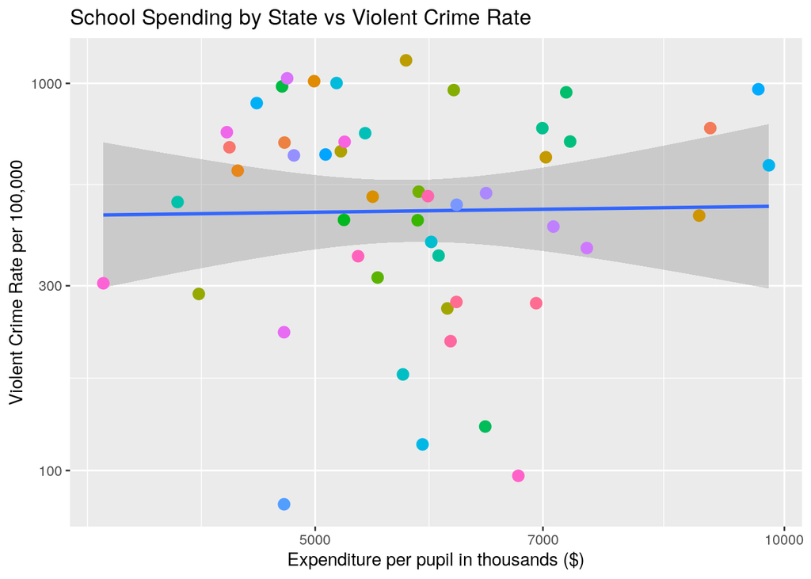

```r
ggplot(year94_set, aes(expendpp, violent)) + geom_point() + geom_smooth(method = lm) +
    geom_point(aes(color = state), size = 3) + theme(legend.position = "none") +
    ggtitle("School Spending by State vs Violent Crime Rate") +
    xlab("Expenditure per pupil in thousands ($)") + ylab("Violent Crime Rate per 100,000") +
    scale_x_log10() + scale_y_log10()
```

*This plot represents the relationship between school expenditures and the violent crime rate per state. Based on the linear regression line, the relationship between does not appear to be strong in any direction.*

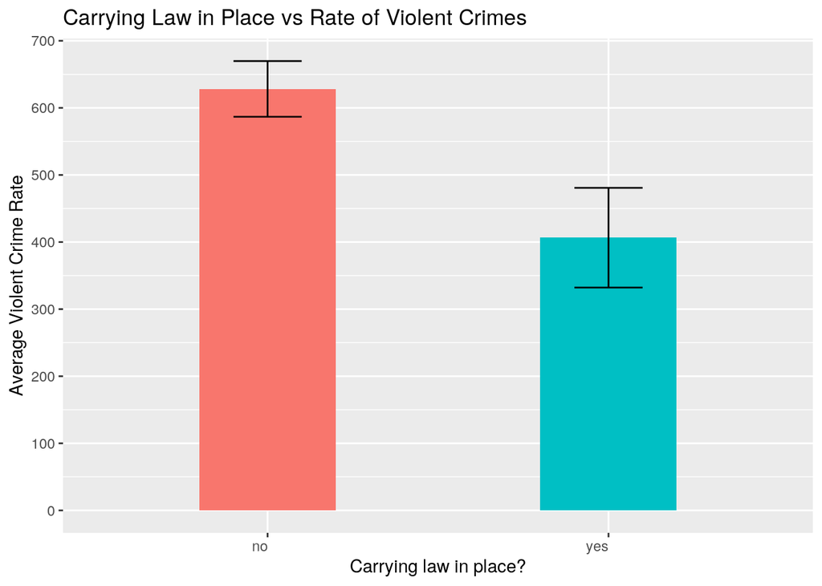

```r
ggplot(year94_set, aes(x = law, y = violent, fill = law)) + geom_bar(stat = "summary",
    position = "dodge", width = 0.4) + geom_errorbar(stat = "summary",
    position = "dodge", width = 0.2) + theme(axis.text.x = element_text(hjust = 1),
    legend.position = "none") + ggtitle("Carrying Law in Place vs Rate of Violent Crimes") +
    xlab("Carrying law in place?") + ylab("Average Violent Crime Rate") +
    scale_y_continuous(n.breaks = 6)
```

*In this plot, there is an obvious difference between the average violent crime rate and whether the state has a carrying law in place or not. The error bars in this plot do not overlap therefore indicating significant difference.*

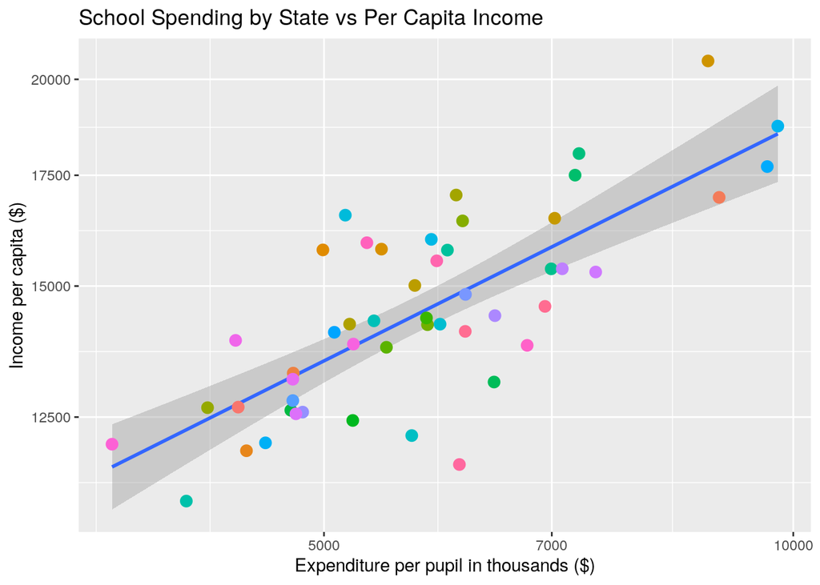

```r
ggplot(year94_set, aes(expendpp, income)) + geom_point() + geom_smooth(method = lm) +
    geom_point(aes(color = state), size = 3) + theme(legend.position = "none") +
    ggtitle("School Spending by State vs Per Capita Income") +
    xlab("Expenditure per pupil in thousands ($)") + ylab("Income per capita ($)") +
    scale_x_log10() + scale_y_log10()
```

*Here, it can be seen that there is a strong positive relationship between the income per capita and expenditure per student. This indicates that states that have relatively higher income per capita will also have schools that generally spend more per student.*